# Resolución Actividad 3 máster Bioinformática UNIR (2023)

Grupo 5

2024-02-11

```r
library(tidyr)
library(stats)
library(FactoMineR)
library(factoextra)
library(kableExtra)
library(tibble)
library(dplyr)
library(nortest)
library(glmnet)
```

Para la resolución de la actividad deberemos empezar cargando la base de datos, explorandola y estandarizando todos los datos asegurandonos así de que todos poseen la misma escala. Para ello, en caso de realizar una PCA necesitaremos a cada variable restarle su media y dividir entre la desviación estandar. De esta forma conseguimos una media de 0 y una desviacion estandar de 1.

```r
# Carga de los datos y exploración
data_1 <- read.csv("./data/mubio02_act3_alimentos_nutrientes_4900.csv")
head(data_1)[, 1:6]
```

```
##   id altura peso      IMC sexo  edad
## 1  1    150   42 18.66667    2 89.75
## 2  2    162   80 30.48316    1 89.75
## 3  3    179   78 24.34381    1 89.50
## 4  4    167   75 26.89232    1 89.00
## 5  5    163   72 27.09925    1 86.75
## 6  6    167   65 23.30668    1 86.00
```

```r
str(data_1)
```

```
## 'data.frame':    4900 obs. of  177 variables:
##  $ id                  : int  1 2 3 4 5 6 7 8 9 10 ...
##  $ altura              : int  150 162 179 167 163 167 165 169 172 182 ...
##  $ peso                : int  42 80 78 75 72 65 72 65 75 98 ...
##  $ IMC                 : num  18.7 30.5 24.3 26.9 27.1 ...
##  $ sexo                : int  2 1 1 1 1 1 1 1 1 1 ...
##  $ edad                : num  89.8 89.8 89.5 89 86.8 ...
##  $ estado_civil        : int  2 1 1 1 1 2 1 1 2 2 ...
##  $ tabaco              : int  0 0 2 2 3 2 2 2 1 2 ...
##  $ colesterol          : int  3 4 4 2 2 3 NA 2 0 2 ...
##  $ hdl                 : int  3 3 0 3 3 3 NA 2 0 2 ...
##  $ HTA                 : int  0 0 3 4 4 4 4 0 0 3 ...
##  $ hipercolesterolemia : int  0 0 0 0 0 0 0 0 0 0 ...
##  $ hipertrigliceridemia: int  0 0 0 0 0 0 0 0 0 0 ...
##  $ ECV_prev            : int  0 0 1 0 0 0 0 0 0 1 ...
```

[output cut: 86 more lines]

```r
# Marcamos la columna "id" como columna idetificadora para futuras referencias
datos_crudos <- data_1  %>%
  column_to_rownames(var = "id")

# Visualización (datos_crudos)

total_nulos <- sum(is.na(datos_crudos))
datos_sin_nulos <- na.omit(datos_crudos)
```

Seleccionmos las columnas categoricas y las transformamos en valores de tipo factor. Esta transformacion a factor se necesitará mas adelante (regresion logistiica, tablas estratificadas, etc).

```r
# Selección de datos para PCA: se usa SOLO las columnas numéricas, sin columna id ni categóricas
lista_columnas_categoricas <- c("sexo", "estado_civil",
                   "tabaco", "colesterol", "hdl",
                   "HTA", "hipercolesterolemia", "hipertrigliceridemia",
                   "ECV_prev", "diab_prev", "hta_prev",
                   "depres_prev", "FA_prev", "cancer_prev")

columnas_categoricas <- datos_sin_nulos[, lista_columnas_categoricas] %>%
  mutate_all(factor)

columnas_numericas <- datos_sin_nulos[, sapply(datos_sin_nulos, is.numeric)] %>%
  select(-one_of(lista_columnas_categoricas))

str(columnas_numericas)
```

```
## 'data.frame':    4334 obs. of  162 variables:
##  $ altura       : int  150 162 179 167 163 167 169 172 182 184 ...
##  $ peso         : int  42 80 78 75 72 65 65 75 98 72 ...
##  $ IMC          : num  18.7 30.5 24.3 26.9 27.1 ...
##  $ edad         : num  89.8 89.8 89.5 89 86.8 ...
##  $ METs_h_semana: num  5.66 57.12 28.22 141.16 12.32 ...
##  $ cereales     : num  77.1 10 33.7 274 149.7 ...
##  $ verdura      : num  921 723 617 1168 577 ...
##  $ fruta        : num  1142 476 176 1005 310 ...
##  $ pescado      : num  128.6 105 31.4 246.4 170 ...
##  $ legumbre     : num  51.4 16 16.6 25.1 16 ...
##  $ lacteos      : num  0 18.7 649.5 64.3 54.3 ...
##  $ carnes       : num  103.6 66.7 44.8 116.2 129.8 ...
##  $ alimento1    : num  0 0 500 0 0 0 200 0 0 0 ...
##  $ alimento2    : num  0 200 0 0 200 0 0 0 0 200 ...
```

[output cut: 86 more lines]

# Comprobar la normalidad de los datos y estandarización de los mismos

```r
columnas_numericas_bien <- columnas_numericas[, apply(columnas_numericas, 2, sd) != 0] # Eliminamos columnas con desviación estandar cero
# Aplicar la prueba de Anderson-Darling a cada variable seleccionada
# y comprobar la normalidad
resultados_normalidad <- columnas_numericas_bien %>%
  gather(key = "variable", value = "valor", ) %>%
  group_by(variable) %>%
  summarise(
    Test_utilizado = "Anderson-Darling",
    Valor_p = ad.test(valor)$p.value
  ) %>%
  mutate(
    Interpretación = if_else(Valor_p > 0.05, "Distribución Normal", "No Normal")
  )

# Crear la Tabla modelo 1 con los resultados de la prueba de Anderson-Darling
kable(resultados_normalidad, col.names = c("Variable", "Test utilizado", "Valor p", "Interpretación"), caption = "Tabla 1. Prueba de normalidad de Anderson-Darling para los alimentos y nutrientes")
```

Tabla 1. Prueba de normalidad de Anderson-Darling para los alimentos y nutrientes

| Variable | Test utilizado | Valor p | Interpretación |
| --- | --- | --- | --- |
| IMC | Anderson-Darling | 0 | No Normal |
| METs_h_semana | Anderson-Darling | 0 | No Normal |
| alimento1 | Anderson-Darling | 0 | No Normal |
| alimento10 | Anderson-Darling | 0 | No Normal |
| alimento100 | Anderson-Darling | 0 | No Normal |
| alimento101 | Anderson-Darling | 0 | No Normal |
| alimento102 | Anderson-Darling | 0 | No Normal |
| alimento103 | Anderson-Darling | 0 | No Normal |
| alimento104 | Anderson-Darling | 0 | No Normal |
| alimento105 | Anderson-Darling | 0 | No Normal |
| alimento106 | Anderson-Darling | 0 | No Normal |
| alimento107 | Anderson-Darling | 0 | No Normal |
| alimento108 | Anderson-Darling | 0 | No Normal |
| alimento109 | Anderson-Darling | 0 | No Normal |
| alimento11 | Anderson-Darling | 0 | No Normal |
| alimento110 | Anderson-Darling | 0 | No Normal |
| alimento111 | Anderson-Darling | 0 | No Normal |
| alimento112 | Anderson-Darling | 0 | No Normal |
| alimento113 | Anderson-Darling | 0 | No Normal |
| alimento114 | Anderson-Darling | 0 | No Normal |
| alimento115 | Anderson-Darling | 0 | No Normal |
| alimento116 | Anderson-Darling | 0 | No Normal |
| alimento117 | Anderson-Darling | 0 | No Normal |
| alimento118 | Anderson-Darling | 0 | No Normal |
| alimento119 | Anderson-Darling | 0 | No Normal |
| alimento12 | Anderson-Darling | 0 | No Normal |
| alimento120 | Anderson-Darling | 0 | No Normal |
| alimento121 | Anderson-Darling | 0 | No Normal |
| alimento122 | Anderson-Darling | 0 | No Normal |
| alimento123 | Anderson-Darling | 0 | No Normal |

[output cut: 132 more lines]

```r
# Estandarización de los datos
columnas_numericas_estandarizadas <- scale(columnas_numericas, center = TRUE, scale = TRUE)
head(columnas_numericas_estandarizadas)
```

```
##       altura        peso        IMC     edad METs_h_semana   cereales
## 1 -2.1039247 -2.05658527 -1.6945625 4.610765    -0.7047315 -0.3845409
## 2 -0.7392508  0.67302058  1.6128065 4.610765     1.5458059 -1.1424346
## 3  1.1940372  0.52935711 -0.1055619 4.582958     0.2817516 -0.8747530
## 4 -0.1706367  0.31386191  0.6077524 4.527343     5.2217190  1.8375390
## 5 -0.6255280  0.09836671  0.6656701 4.277075    -0.4136896  0.4346293
## 6 -0.1706367 -0.40445542 -0.3958487 4.193652    -0.8364377 -1.1875857
##        verdura      fruta     pescado     legumbre    lacteos     carnes
## 1  0.743669959  2.1792083  0.20390265  0.948536129 -0.8864270 -0.7260610
## 2  0.310448967  0.2024889 -0.06393008 -0.317585994 -0.7918499 -1.0994282
## 3  0.079570714 -0.6859402 -0.89766743 -0.297164669  2.4044690 -1.3210398
## 4  1.280656458  1.7710111  1.53982637  0.009155199 -0.5607151 -0.5983935
## 5 -0.006035829 -0.2898901  0.67368989 -0.317585994 -0.6113814 -0.4610908
## 6 -0.874034296 -0.1047183  0.54409341  0.029576524 -0.5607151 -0.6610229
##    alimento1  alimento2  alimento3  alimento4  alimento5  alimento6  alimento7
```

[output cut: 167 more lines]

```r
datos_estandarizados <- cbind(columnas_categoricas, columnas_numericas_estandarizadas)

str(datos_estandarizados)
```

```
## 'data.frame':    4334 obs. of  176 variables:
##  $ sexo                : Factor w/ 2 levels "1","2": 2 1 1 1 1 1 1 1 1 1 ...
##  $ estado_civil        : Factor w/ 5 levels "0","1","2","3",..: 3 2 2 2 2 3 2 3 3 2 ...
##  $ tabaco              : Factor w/ 4 levels "0","1","2","3": 1 1 3 3 4 3 3 2 3 1 ...
##  $ colesterol          : Factor w/ 7 levels "0","1","2","3",..: 4 5 5 3 3 4 3 1 3 3 ...
##  $ hdl                 : Factor w/ 5 levels "0","1","2","3",..: 4 4 1 4 4 4 3 1 3 2 ...
##  $ HTA                 : Factor w/ 5 levels "0","1","2","3",..: 1 1 4 5 5 5 1 1 4 1 ...
##  $ hipercolesterolemia : Factor w/ 5 levels "0","1","2","3",..: 1 1 1 1 1 1 1 1 1 1 ...
##  $ hipertrigliceridemia: Factor w/ 5 levels "0","1","2","3",..: 1 1 1 1 1 1 1 1 1 1 ...
##  $ ECV_prev            : Factor w/ 2 levels "0","1": 1 1 2 1 1 1 1 1 2 1 ...
##  $ diab_prev           : Factor w/ 2 levels "0","1": 1 2 1 1 1 2 1 1 1 1 ...
##  $ hta_prev            : Factor w/ 2 levels "0","1": 1 1 2 2 2 2 1 1 2 1 ...
##  $ depres_prev         : Factor w/ 2 levels "0","1": 1 1 1 1 1 1 1 1 2 1 ...
##  $ FA_prev             : Factor w/ 2 levels "0","1": 1 1 1 1 1 1 1 1 1 1 ...
##  $ cancer_prev         : Factor w/ 2 levels "0","1": 1 2 1 1 1 1 1 1 1 1 ...
```

[output cut: 86 more lines]

Una vez tenemos todos los datos en la misma escala procedemos a la realización de la PCA.

```r
# PCA
datosPCA <- prcomp(columnas_numericas_estandarizadas)
summary(datosPCA)
```

```
## Importance of components:
##                           PC1     PC2    PC3     PC4    PC5     PC6     PC7
## Standard deviation     4.3220 2.49553 2.0757 1.87890 1.8223 1.75964 1.68454
## Proportion of Variance 0.1153 0.03844 0.0266 0.02179 0.0205 0.01911 0.01752
## Cumulative Proportion  0.1153 0.15375 0.1803 0.20213 0.2226 0.24175 0.25926
##                            PC8     PC9    PC10    PC11    PC12    PC13    PC14
## Standard deviation     1.62379 1.58513 1.57317 1.54637 1.45559 1.40470 1.36999
## Proportion of Variance 0.01628 0.01551 0.01528 0.01476 0.01308 0.01218 0.01159
## Cumulative Proportion  0.27554 0.29105 0.30632 0.32109 0.33416 0.34634 0.35793
##                          PC15    PC16    PC17    PC18    PC19    PC20    PC21
## Standard deviation     1.3468 1.32769 1.30705 1.28270 1.25400 1.22633 1.21664
## Proportion of Variance 0.0112 0.01088 0.01055 0.01016 0.00971 0.00928 0.00914
## Cumulative Proportion  0.3691 0.38001 0.39055 0.40071 0.41042 0.41970 0.42884
##                           PC22    PC23    PC24    PC25    PC26    PC27    PC28
## Standard deviation     1.21046 1.20683 1.19657 1.17843 1.17267 1.16782 1.15698
## Proportion of Variance 0.00904 0.00899 0.00884 0.00857 0.00849 0.00842 0.00826
## Cumulative Proportion  0.43788 0.44687 0.45571 0.46428 0.47277 0.48119 0.48945
##                           PC29    PC30    PC31    PC32    PC33    PC34    PC35
## Standard deviation     1.14431 1.13296 1.12125 1.11911 1.10902 1.10496 1.09902
## Proportion of Variance 0.00808 0.00792 0.00776 0.00773 0.00759 0.00754 0.00746
## Cumulative Proportion  0.49753 0.50546 0.51322 0.52095 0.52854 0.53608 0.54353
##                           PC36    PC37    PC38    PC39    PC40    PC41    PC42
## Standard deviation     1.09355 1.08599 1.07766 1.07680 1.06531 1.06434 1.05645
## Proportion of Variance 0.00738 0.00728 0.00717 0.00716 0.00701 0.00699 0.00689
## Cumulative Proportion  0.55092 0.55820 0.56537 0.57252 0.57953 0.58652 0.59341
##                           PC43    PC44    PC45    PC46    PC47    PC48    PC49
## Standard deviation     1.04708 1.03956 1.03882 1.02867 1.02021 1.01624 1.01087
## Proportion of Variance 0.00677 0.00667 0.00666 0.00653 0.00642 0.00637 0.00631
## Cumulative Proportion  0.60018 0.60685 0.61351 0.62004 0.62647 0.63284 0.63915
##                           PC50    PC51    PC52   PC53    PC54    PC55    PC56
## Standard deviation     1.00807 1.00459 0.99709 0.9939 0.98986 0.98694 0.98134
## Proportion of Variance 0.00627 0.00623 0.00614 0.0061 0.00605 0.00601 0.00594
## Cumulative Proportion  0.64542 0.65165 0.65779 0.6639 0.66994 0.67595 0.68189
##                          PC57    PC58    PC59    PC60    PC61    PC62    PC63
## Standard deviation     0.9776 0.97550 0.96624 0.96385 0.95729 0.95616 0.94894
## Proportion of Variance 0.0059 0.00587 0.00576 0.00573 0.00566 0.00564 0.00556
## Cumulative Proportion  0.6878 0.69367 0.69943 0.70516 0.71082 0.71646 0.72202
##                           PC64    PC65    PC66   PC67    PC68    PC69    PC70
## Standard deviation     0.94460 0.94259 0.93958 0.9351 0.93136 0.92810 0.92096
## Proportion of Variance 0.00551 0.00548 0.00545 0.0054 0.00535 0.00532 0.00524
```

[output cut: 46 more lines]

```
## Standard deviation     1.466e-15 1.352e-15 1.204e-15 1.139e-15 1.088e-15
## Proportion of Variance 0.000e+00 0.000e+00 0.000e+00 0.000e+00 0.000e+00
## Cumulative Proportion  1.000e+00 1.000e+00 1.000e+00 1.000e+00 1.000e+00
##                            PC150     PC151     PC152     PC153     PC154
## Standard deviation     1.084e-15 1.056e-15 9.331e-16 8.863e-16 8.401e-16
## Proportion of Variance 0.000e+00 0.000e+00 0.000e+00 0.000e+00 0.000e+00
## Cumulative Proportion  1.000e+00 1.000e+00 1.000e+00 1.000e+00 1.000e+00
##                            PC155     PC156     PC157     PC158     PC159
## Standard deviation     8.324e-16 7.948e-16 7.514e-16 7.153e-16 6.175e-16
## Proportion of Variance 0.000e+00 0.000e+00 0.000e+00 0.000e+00 0.000e+00
## Cumulative Proportion  1.000e+00 1.000e+00 1.000e+00 1.000e+00 1.000e+00
##                            PC160     PC161     PC162
## Standard deviation     5.862e-16 5.594e-16 4.883e-16
## Proportion of Variance 0.000e+00 0.000e+00 0.000e+00
## Cumulative Proportion  1.000e+00 1.000e+00 1.000e+00
```

Segun la regla del codo, escogemos dos para facilitar la visualizacion y analizamos el PCA.

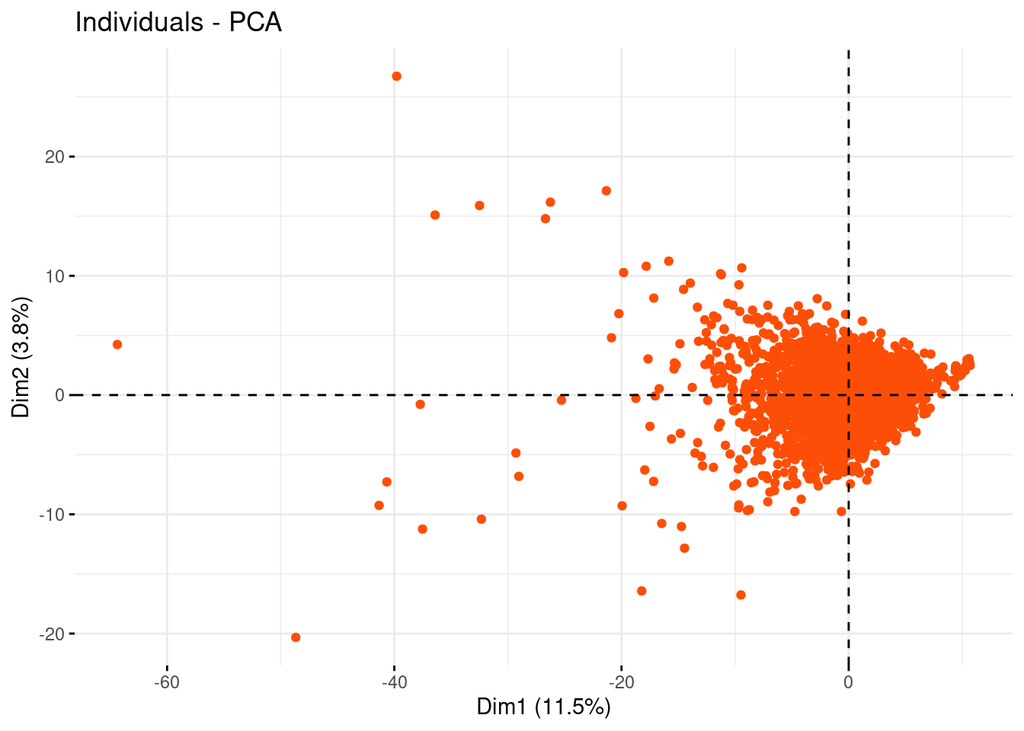

```r
# Análisis PCA
fviz_pca_ind(datosPCA, geom.ind = "point",
             col.ind = "#FC4E07",
             axes = c(1, 2),
             pointsize = 1.5)
```

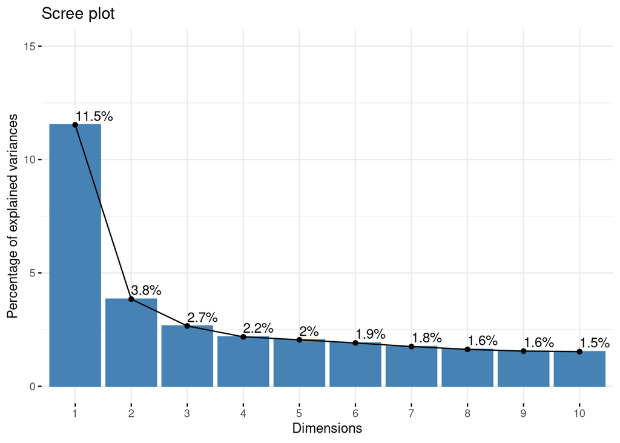

```r
# Scree plot de los PCs
fviz_screeplot(datosPCA, addlabels = TRUE, ylim = c(0, 15))
```

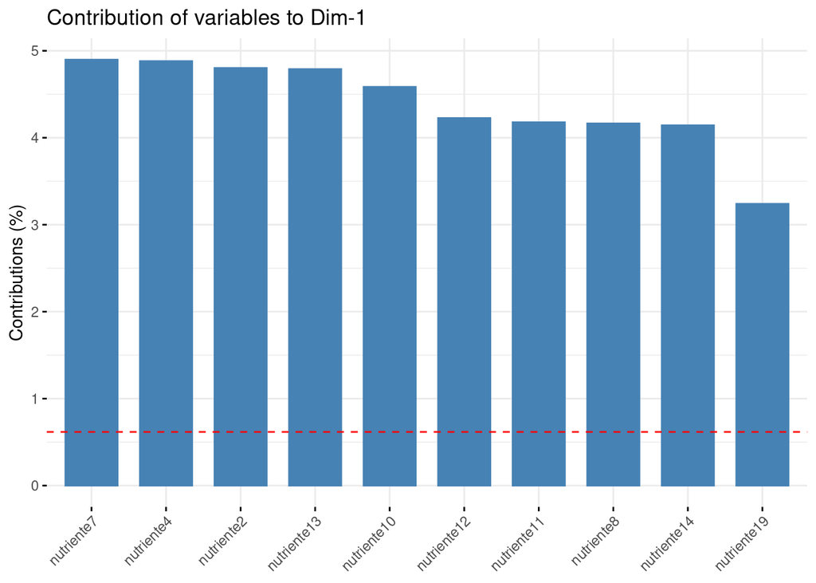

```r
# Scree plot de las variables
fviz_contrib(datosPCA, choice = "var", axes = 1, top = 10)
```

Se comprueba que los 5 nutrientes con mayor influencia en el PC1 son los nutrientes 7, 4, 2, 13 y 10.

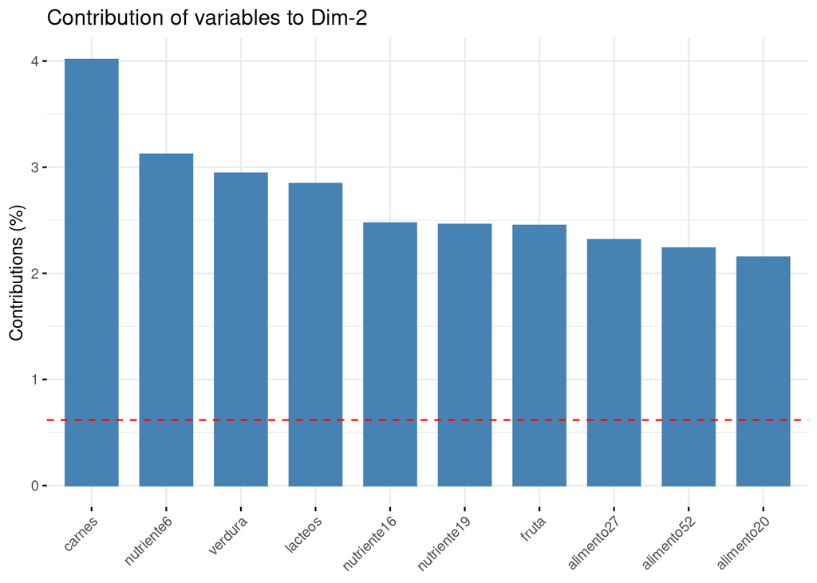

```r
fviz_contrib(datosPCA, choice = "var", axes = 2, top = 10)
```

El en caso del componente principal 2, se observa que la variable más influyente es la relativa al consumo de carne.

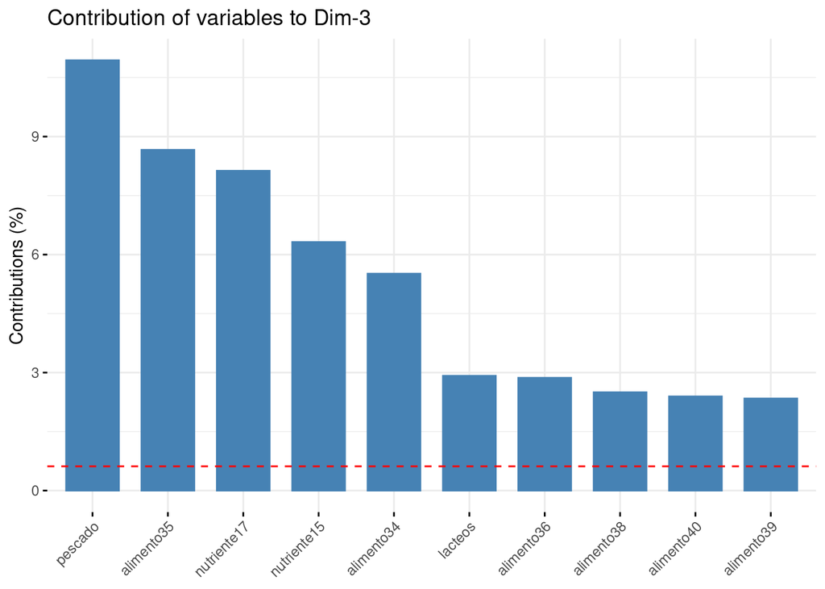

```r
fviz_contrib(datosPCA, choice = "var", axes = 3, top = 10)
```

En el caso del PC3, los alimentos más representados son el pescado, el alimento etiquetado como 35, y los nutrientes 17 y 15.

```r
# Proporción de varianza explicada por cada componente principal
prop_var_explicada <- (datosPCA$sdev^2) / sum(datosPCA$sdev^2)

# Crear un dataframe con los componentes y su proporción de varianza explicada
df_componentes <- data.frame(Componente = paste0("Componente ", 1:length(prop_var_explicada)),
                              R2 = prop_var_explicada)

# Imprimir el dataframe
print(df_componentes)
```

```
##         Componente           R2
## 1     Componente 1 1.153049e-01
## 2     Componente 2 3.844244e-02
## 3     Componente 3 2.659504e-02
## 4     Componente 4 2.179173e-02
## 5     Componente 5 2.049793e-02
## 6     Componente 6 1.911323e-02
## 7     Componente 7 1.751654e-02
## 8     Componente 8 1.627591e-02
## 9     Componente 9 1.551019e-02
## 10   Componente 10 1.527695e-02
## 11   Componente 11 1.476095e-02
## 12   Componente 12 1.307873e-02
## 13   Componente 13 1.218008e-02
## 14   Componente 14 1.158567e-02
```

[output cut: 148 more lines]

Establecemos categorías por los terciles de los PCA. Para la regresion logística es más facil representarlo como categorías en una misma columna que como columnas separadas. separadas

```r
# Regresión logística

datosPCA$rotation[,1]
```

```
##        altura          peso           IMC          edad METs_h_semana
##  0.0240871905  0.0140884362  0.0010970675 -0.0117123136 -0.0245299882
##      cereales       verdura         fruta       pescado      legumbre
## -0.0751431707 -0.1663228618 -0.1343285579 -0.1230155747 -0.1000438731
##       lacteos        carnes     alimento1     alimento2     alimento3
## -0.0393783397 -0.1026516267 -0.0140578126 -0.0254924301 -0.0386369304
##     alimento4     alimento5     alimento6     alimento7     alimento8
## -0.0012401998 -0.0099966647 -0.0109670871 -0.0252531960 -0.0500954066
##     alimento9    alimento10    alimento11    alimento12    alimento13
## -0.0064442047 -0.0276223003 -0.0338124746 -0.0551896933 -0.0662240181
##    alimento14    alimento15    alimento16    alimento17    alimento18
## -0.0274517705 -0.0143850773 -0.0374794923 -0.0237573043 -0.0631485438
##    alimento19    alimento20    alimento21    alimento22    alimento23
## -0.0455214294 -0.0340563981 -0.0353358694 -0.0452938161 -0.0484197332
##    alimento24    alimento25    alimento26    alimento27    alimento28
## -0.0150161315 -0.0738234834 -0.0599514459 -0.0257075983 -0.0169893093
##    alimento29    alimento30    alimento31    alimento32    alimento33
## -0.0293671603 -0.0224786802 -0.0147905849 -0.0194560696 -0.0164372963
##    alimento34    alimento35    alimento36    alimento37    alimento38
## -0.0857891835 -0.0987400236 -0.0709470343 -0.0592792915 -0.0640668258
##    alimento39    alimento40    alimento41    alimento42    alimento43
## -0.0611021894 -0.0790266423 -0.1127079417 -0.1038834665 -0.1040201739
##    alimento44    alimento45    alimento46    alimento47    alimento48
## -0.1080837113 -0.1095712145 -0.1159619347 -0.1035772809 -0.0971155666
##    alimento49    alimento50    alimento51    alimento52    alimento53
## -0.0795302131 -0.0432618001 -0.0659267680 -0.0365457311 -0.0713660797
##    alimento54    alimento55    alimento56    alimento57    alimento58
## -0.0703871475 -0.0402145048 -0.0759185181 -0.0742786948 -0.0803168849
##    alimento59    alimento60    alimento61    alimento62    alimento63
## -0.0843839757 -0.0463551448 -0.0684265772 -0.0729215241 -0.0710294188
##    alimento64    alimento65    alimento66    alimento67    alimento68
## -0.0289168487 -0.0304253887 -0.0455225436 -0.0613561151 -0.0532411469
##    alimento69    alimento70    alimento71    alimento72    alimento73
## -0.0543434746 -0.0451870239 -0.0597323921 -0.0861881001 -0.0820955119
##    alimento74    alimento75    alimento76    alimento77    alimento78
## -0.0736859998 -0.0576968337 -0.0334278759 -0.0461069767 -0.0463562948
##    alimento79    alimento80    alimento81    alimento82    alimento83
## -0.0698750200 -0.0576619990 -0.0177972016 -0.0043231619 -0.0084624093
##    alimento84    alimento85    alimento86    alimento87    alimento88
## -0.0510366205 -0.0238325016 -0.0093781442 -0.0063709621 -0.0093105705
```

[output cut: 11 more lines]

```
## -0.0147583152 -0.0512603387 -0.0353245075 -0.0099631569 -0.0262140103
##   alimento119   alimento120   alimento121   alimento122   alimento123
## -0.0188582674 -0.0187467004 -0.0282632499 -0.0213420586 -0.0178490457
##   alimento124   alimento125   alimento126   alimento127   alimento128
## -0.0256920479 -0.0156049840 -0.0145320587 -0.0199742265 -0.0022878587
##   alimento129   alimento130   alimento131    nutriente1    nutriente2
## -0.0217145944 -0.0131368589 -0.0211439510 -0.1714868919 -0.2191361045
##    nutriente3    nutriente4    nutriente5    nutriente6    nutriente7
## -0.1036936682 -0.2209270275 -0.1238403256 -0.0834363121 -0.2213056582
##    nutriente8    nutriente9   nutriente10   nutriente11   nutriente12
## -0.2040667591 -0.1446452433 -0.2141197842 -0.2043917153 -0.2055785927
##   nutriente13   nutriente14   nutriente15   nutriente16   nutriente17
## -0.2188415744 -0.2035412515 -0.1352750649 -0.1572359049 -0.1129655874
##   nutriente18   nutriente19
## -0.1251237160 -0.1799882377
```

```r
datosPCA$rotation[,2]
```

```
##        altura          peso           IMC          edad METs_h_semana
## -0.0902197316 -0.0778897112 -0.0405492268  0.0647950913  0.0316958878
##      cereales       verdura         fruta       pescado      legumbre
## -0.0846556743  0.1715021501  0.1565323428 -0.0496878909 -0.0250594727
##       lacteos        carnes     alimento1     alimento2     alimento3
## -0.1686510567 -0.2003141766 -0.1227661063 -0.0213391007  0.0588069318
##     alimento4     alimento5     alimento6     alimento7     alimento8
## -0.0091178427 -0.0379322299 -0.0405834494 -0.0759399676  0.0898466596
##     alimento9    alimento10    alimento11    alimento12    alimento13
## -0.0436826750 -0.0356705011 -0.0235542971 -0.0750531401  0.0091412488
##    alimento14    alimento15    alimento16    alimento17    alimento18
## -0.1231569765 -0.0461215713 -0.1063535471 -0.0882919539  0.0017560220
##    alimento19    alimento20    alimento21    alimento22    alimento23
## -0.1142948006 -0.1466706156 -0.0662531751 -0.0262703912 -0.0912667723
##    alimento24    alimento25    alimento26    alimento27    alimento28
## -0.0357174455 -0.0893356584 -0.0537785819 -0.1521510799 -0.1328451543
##    alimento29    alimento30    alimento31    alimento32    alimento33
## -0.1222179885 -0.1066785279 -0.1077878945 -0.1008637548 -0.1219234298
##    alimento34    alimento35    alimento36    alimento37    alimento38
## -0.0030395241 -0.0388109739 -0.0228311726 -0.0737589047 -0.0737798763
##    alimento39    alimento40    alimento41    alimento42    alimento43
## -0.0779108057 -0.0806129937  0.0938478018  0.0754365871  0.1138757778
##    alimento44    alimento45    alimento46    alimento47    alimento48
##  0.1228240780  0.1435358303  0.0961522526  0.1313718596  0.0858265502
##    alimento49    alimento50    alimento51    alimento52    alimento53
##  0.0598425326  0.0633225679  0.0427691641 -0.1495575084 -0.0367151124
##    alimento54    alimento55    alimento56    alimento57    alimento58
##  0.0705013192  0.0007284425  0.0956689486  0.0944177965  0.1060115921
##    alimento59    alimento60    alimento61    alimento62    alimento63
##  0.0927933499  0.0490627463  0.1013034634  0.0996343815  0.0684234102
##    alimento64    alimento65    alimento66    alimento67    alimento68
## -0.0619960279  0.0131659102  0.0304975572 -0.0023677845 -0.0395969197
##    alimento69    alimento70    alimento71    alimento72    alimento73
##  0.0094130530  0.0637820329  0.1031542127 -0.0160132298 -0.0206092768
##    alimento74    alimento75    alimento76    alimento77    alimento78
## -0.0363132429 -0.0076008976 -0.1125023161  0.0684009451  0.0108880393
##    alimento79    alimento80    alimento81    alimento82    alimento83
## -0.0389805182 -0.0735068505 -0.0629931044 -0.0523148631 -0.0385437692
##    alimento84    alimento85    alimento86    alimento87    alimento88
##  0.0147461125 -0.0452397072  0.0009816843 -0.0465127428  0.0083315195
```

[output cut: 11 more lines]

```
## -0.0259147042  0.0152023860  0.0240475571 -0.0271654721  0.0051041574
##   alimento119   alimento120   alimento121   alimento122   alimento123
## -0.0561280962 -0.0148255594  0.0455926916 -0.1142381669 -0.1066445814
##   alimento124   alimento125   alimento126   alimento127   alimento128
## -0.1053848668 -0.0879074266 -0.0282298369 -0.0349915113 -0.1057788948
##   alimento129   alimento130   alimento131    nutriente1    nutriente2
##  0.0411363756 -0.0262460906 -0.0021940799 -0.0478536835 -0.0135594661
##    nutriente3    nutriente4    nutriente5    nutriente6    nutriente7
## -0.0400147063 -0.0036295503  0.0263481749 -0.1766392404  0.0553663174
##    nutriente8    nutriente9   nutriente10   nutriente11   nutriente12
## -0.0994073314 -0.0866564485 -0.0372318358 -0.0604410899 -0.1184365916
##   nutriente13   nutriente14   nutriente15   nutriente16   nutriente17
##  0.0222352716  0.1134823412 -0.1354880876  0.1572257536 -0.0622533124
##   nutriente18   nutriente19
## -0.0775941416  0.1568229054
```

```r
datosPCA$rotation[,3]
```

```
##        altura          peso           IMC          edad METs_h_semana
##  0.0283857245  0.0947728150  0.1116654805  0.0878615573  0.0226492686
##      cereales       verdura         fruta       pescado      legumbre
## -0.1506049284 -0.0672510086 -0.0491561800  0.3307478698 -0.0019584640
##       lacteos        carnes     alimento1     alimento2     alimento3
## -0.1707947337  0.0428093561 -0.1377164313 -0.0105046753  0.0595365487
##     alimento4     alimento5     alimento6     alimento7     alimento8
## -0.0066280195 -0.0343013279 -0.0292452985 -0.1080685193  0.1301831243
##     alimento9    alimento10    alimento11    alimento12    alimento13
## -0.0221417756 -0.0134755153 -0.0412531117 -0.0366508177  0.0571944577
##    alimento14    alimento15    alimento16    alimento17    alimento18
## -0.0648263521 -0.0198420339 -0.0503772970  0.0014576348  0.0272836466
##    alimento19    alimento20    alimento21    alimento22    alimento23
## -0.0089090877 -0.0463388596  0.1031386042  0.0697307353  0.0536177270
##    alimento24    alimento25    alimento26    alimento27    alimento28
##  0.0325892906  0.1192543889  0.0186235600 -0.0284731578 -0.0350104706
##    alimento29    alimento30    alimento31    alimento32    alimento33
## -0.0151121221  0.0149075343 -0.0295181970 -0.0471984624 -0.0419095641
##    alimento34    alimento35    alimento36    alimento37    alimento38
##  0.2348198270  0.2943231070  0.1693124769  0.1398849078  0.1580730291
##    alimento39    alimento40    alimento41    alimento42    alimento43
##  0.1529692787  0.1547120936 -0.0408548873 -0.0130480643 -0.0571666753
##    alimento44    alimento45    alimento46    alimento47    alimento48
## -0.0479939547 -0.0614563247 -0.0618377512 -0.0337264980 -0.0235583289
##    alimento49    alimento50    alimento51    alimento52    alimento53
##  0.0160956278 -0.0063195051 -0.0435153584 -0.0374579375 -0.0554705981
##    alimento54    alimento55    alimento56    alimento57    alimento58
## -0.0211063260 -0.0622070703 -0.0254172589 -0.0299197189 -0.0271276253
##    alimento59    alimento60    alimento61    alimento62    alimento63
## -0.0223310681 -0.0242161437 -0.0128038958 -0.0264001260 -0.0463573986
##    alimento64    alimento65    alimento66    alimento67    alimento68
## -0.0474406341 -0.0006424596 -0.0315857176 -0.0158116062 -0.0140223672
##    alimento69    alimento70    alimento71    alimento72    alimento73
##  0.0382264448 -0.0034823283 -0.0153182402 -0.0267861072 -0.0112095665
##    alimento74    alimento75    alimento76    alimento77    alimento78
##  0.0182599652  0.0053308364 -0.1503093908 -0.0024307505 -0.0028673979
##    alimento79    alimento80    alimento81    alimento82    alimento83
## -0.0400773958 -0.0736601645 -0.0481291204 -0.0794007264 -0.0647105165
##    alimento84    alimento85    alimento86    alimento87    alimento88
## -0.0626141026 -0.0686193813  0.0102454528 -0.0056631749 -0.0132858632
```

[output cut: 11 more lines]

```
##  0.0525705537 -0.0187367041 -0.0169565181 -0.0198318352  0.0101185680
##   alimento119   alimento120   alimento121   alimento122   alimento123
## -0.0235725630 -0.0663828016  0.0598013638 -0.0672280960 -0.0591635649
##   alimento124   alimento125   alimento126   alimento127   alimento128
## -0.0261339051 -0.0413396741 -0.0027813212 -0.0547816750 -0.1051236878
##   alimento129   alimento130   alimento131    nutriente1    nutriente2
##  0.0524147754 -0.0785249125 -0.0335380789 -0.0584431319 -0.0541641447
##    nutriente3    nutriente4    nutriente5    nutriente6    nutriente7
## -0.0290213492 -0.0494287327  0.0948474291 -0.0661977800 -0.0518930850
##    nutriente8    nutriente9   nutriente10   nutriente11   nutriente12
##  0.0106217970 -0.1520557130 -0.0368719575 -0.0234636764  0.0852413325
##   nutriente13   nutriente14   nutriente15   nutriente16   nutriente17
##  0.0612810101 -0.0558390834  0.2513484311 -0.0795754844  0.2851349456
##   nutriente18   nutriente19
## -0.0657776356 -0.0621092629
```

```r
# agregarmos los 3 PC seleccionados al final del dataframe
datos_completos <- cbind(datos_estandarizados, datosPCA$x[, 1:3])

# Creamos un subconjunto con las tres columnas PC1, PC2 y PC3
columnas_pc <- datos_completos[, paste("PC",1:3, sep = "")]
# head(columnas_pc)

for(i in 1:3) {
  columna_terciles <- cut(columnas_pc[[i]], breaks = quantile(columnas_pc[[i]], probs = seq(0, 1, by = 1/3)), labels = c("1", "2", "3"), include.lowest = TRUE)
  datos_completos[paste(names(columnas_pc)[i], "tercil", sep = "_")] <- columna_terciles
}

summary(datos_completos)
```

```
##  sexo     estado_civil tabaco   colesterol hdl      HTA
##  1:2200   0: 715       0:1613   0: 388     0: 619   0:3698
##  2:2134   1:3260       1: 857   1: 327     1:1161   1:  35
##           2:  79       2:1835   2: 902     2: 273   2: 232
##           3: 213       3:  29   3:1426     3:1871   3: 341
##           4:  67                4: 997     4: 410   4:  28
##                                 5: 277
##                                 6:  17
##  hipercolesterolemia hipertrigliceridemia ECV_prev diab_prev hta_prev
##  0:3193              0:3813               0:4205   0:4044    0:3462
##  1:  69              1:  34               1: 129   1: 290    1: 872
##  2: 583              2: 270
##  3: 459              3: 205
##  4:  30              4:  12
##
##
##  depres_prev FA_prev  cancer_prev     altura              peso
##  0:3687      0:4311   0:4182      Min.   :-4.83327   Min.   :-2.3439
##  1: 647      1:  23   1: 152      1st Qu.:-0.73925   1st Qu.:-0.7636
##                                   Median :-0.05691   Median :-0.0453
##                                   Mean   : 0.00000   Mean   : 0.0000
##                                   3rd Qu.: 0.73915   3rd Qu.: 0.6730
##                                   Max.   : 3.46849   Max.   : 4.9829
##
##       IMC               edad         METs_h_semana        cereales
##  Min.   :-2.5093   Min.   :-1.3678   Min.   :-0.9380   Min.   :-1.2553
##  1st Qu.:-0.7045   1st Qu.:-0.8117   1st Qu.:-0.6786   1st Qu.:-0.5845
##  Median :-0.0770   Median :-0.1443   Median :-0.2492   Median :-0.3128
##  Mean   : 0.0000   Mean   : 0.0000   Mean   : 0.0000   Mean   : 0.0000
##  3rd Qu.: 0.5623   3rd Qu.: 0.5509   3rd Qu.: 0.3421   3rd Qu.: 0.5798
##  Max.   : 5.4482   Max.   : 4.6108   Max.   :13.5702   Max.   : 6.9686
##
##     verdura            fruta            pescado           legumbre
##  Min.   :-1.2642   Min.   :-1.2085   Min.   :-1.2541   Min.   :-0.8894
##  1st Qu.:-0.5430   1st Qu.:-0.6261   1st Qu.:-0.5413   1st Qu.:-0.3176
##  Median :-0.1954   Median :-0.2534   Median :-0.1395   Median :-0.1542
##  Mean   : 0.0000   Mean   : 0.0000   Mean   : 0.0000   Mean   : 0.0000
##  3rd Qu.: 0.2715   3rd Qu.: 0.3307   3rd Qu.: 0.4307   3rd Qu.: 0.1725
##  Max.   :16.8221   Max.   : 8.6075   Max.   :27.2566   Max.   :31.2742
##
```

[output cut: 305 more lines]

```
##  Min.   :-64.3797   Min.   :-20.32179   Min.   :-15.38600   1:1445
##  1st Qu.: -1.6846   1st Qu.: -1.33492   1st Qu.: -1.05376   2:1444
##  Median :  0.6348   Median :  0.07206   Median : -0.03552   3:1445
##  Mean   :  0.0000   Mean   :  0.00000   Mean   :  0.00000
##  3rd Qu.:  2.5329   3rd Qu.:  1.39181   3rd Qu.:  0.98301
##  Max.   : 10.6983   Max.   : 26.73924   Max.   : 42.93091
##
##  PC2_tercil PC3_tercil
##  1:1445     1:1445
##  2:1444     2:1444
##  3:1445     3:1445
##
##
##
##
```

```r
# Regresión logística
modelo_logistica <- glm(diab_prev ~ PC1_tercil + PC2_tercil + sexo, data = datos_completos, family = binomial)
summary(modelo_logistica)
```

```
##
## Call:
## glm(formula = diab_prev ~ PC1_tercil + PC2_tercil + sexo, family = binomial,
##     data = datos_completos)
##
## Coefficients:
##             Estimate Std. Error z value Pr(>|z|)
## (Intercept)  -2.6467     0.1544 -17.145  < 2e-16 ***
## PC1_tercil2  -0.1064     0.1502  -0.708   0.4790
## PC1_tercil3  -0.3937     0.1556  -2.529   0.0114 *
## PC2_tercil2   0.7674     0.1674   4.585 4.54e-06 ***
## PC2_tercil3   1.1134     0.1666   6.685 2.31e-11 ***
## sexo2        -1.3251     0.1430  -9.269  < 2e-16 ***
## ---
## Signif. codes:  0 '***' 0.001 '**' 0.01 '*' 0.05 '.' 0.1 ' ' 1
##
## (Dispersion parameter for binomial family taken to be 1)
##
##     Null deviance: 2128.7  on 4333  degrees of freedom
## Residual deviance: 2008.8  on 4328  degrees of freedom
## AIC: 2020.8
##
## Number of Fisher Scoring iterations: 6
```

**Interpretación:** Los coeficientes para PC1, tienen valores P comparativamente altos, especialmente para el tercil 2. Sin embargo, los de PC2 tienen una alta significancia (valores P muy pequeños). Por tanto, podemos establecer que las variables agrupadas bajo el componente PC2 tienen mayor relacion con la variable objetivo.

Así mismo, el sexo parece tener una gran influencia sobre la incidencia de diabetes. En concreto, pertenecer al sexo etiquetado como “2” (correspondiente a mujer) está inversamente relacionado con la probabilidad de desarrollar diabetes.

Dada la baja influencia del PC1 para nuestro análisis, incluimos el PC3, para comprobar si tienen o no incidencia:

```r
# Regresión logística
modelo_logistica <- glm(diab_prev ~ PC2_tercil + PC3_tercil + sexo, data = datos_completos, family = binomial)
summary(modelo_logistica)
```

```
##
## Call:
## glm(formula = diab_prev ~ PC2_tercil + PC3_tercil + sexo, family = binomial,
##     data = datos_completos)
##
## Coefficients:
##             Estimate Std. Error z value Pr(>|z|)
## (Intercept)  -3.6166     0.2031 -17.811  < 2e-16 ***
## PC2_tercil2   0.4964     0.1683   2.950 0.003181 **
## PC2_tercil3   0.8114     0.1700   4.772 1.82e-06 ***
## PC3_tercil2   0.7293     0.2130   3.425 0.000615 ***
## PC3_tercil3   1.4545     0.1986   7.323 2.43e-13 ***
## sexo2        -1.0479     0.1446  -7.245 4.32e-13 ***
## ---
## Signif. codes:  0 '***' 0.001 '**' 0.01 '*' 0.05 '.' 0.1 ' ' 1
##
## (Dispersion parameter for binomial family taken to be 1)
##
##     Null deviance: 2128.7  on 4333  degrees of freedom
## Residual deviance: 1942.9  on 4328  degrees of freedom
## AIC: 1954.9
##
## Number of Fisher Scoring iterations: 6
```

**Interpretación:** Los coeficientes para PC3, tienen valores P muy bajos, lo que implica que este componente tiene una alta significación para la prevalencia de diabetes. En este caso, parece que la relación es directamente proporcional, como en el caso de PC2.

De momento, este es el modelo que seleccionamos, ya que las tres variables tienen una alta significación para la variable objetivo.

```r
# Cálculo de la odds ratio y visualización en una única tabla
exp(cbind("Odds Ratio" =  coef(modelo_logistica),  confint(modelo_logistica)))
```

```
##             Odds Ratio      2.5 %     97.5 %
## (Intercept) 0.02687331 0.01772306 0.03935148
## PC2_tercil2 1.64286133 1.18493264 2.29456041
## PC2_tercil3 2.25095338 1.61893094 3.15568556
## PC3_tercil2 2.07363260 1.37895669 3.18635861
## PC3_tercil3 4.28237399 2.93976655 6.41968256
## sexo2       0.35067251 0.26281341 0.46362492
```

Si nos basamos en estos valores, hemos obtenido unos coeﬁcientes positivos para los dos PC: a medida que aumenta su valor, mayor es el efecto de dichas variables sobre la respuesta. En el caso de la variable sexo, al tener unos valores de intervalo de confianza por debajo de uno, combinado con el odds ratio menor que uno, confirma que el sexo femenino influye negativamente en la probabilidad de desarrollar diabetes.